# Informe de Coyuntura de Cataluña

## 4º Trimestre de 2020

#### Realizado por Ana Moraza González.

#### ÍNDICE:

1. Resumen
2. Actividad productiva
3. Demanda
4. Mercado de trabajo
5. Impacto de la crisis

### 1. Resumen

- El presente informe describe la situación económica de Cataluña en el 4º trimestre de 2020.
- El impacto de la crisis sanitaria derivado de la pandemia del COVID-19 ha supuesto una reducción de la actividad económica sin precedentes, con caídas en la tasa de variación interanual del PIB superiores al 10%.
- La variación interanual del PIB tocó un mínimo de -25% en el segundo trimestre de 2020, situándose todavía ligeramente por debajo del -10% en el último trimestre.
- Otros indicadores económicos han sufrido igualmente el impacto de la crisis sanitaria, como el Índice de Producción Industrial, con caídas superiores al 20%, aunque este indicador muestra una mayor recuperación, abandonando las tasas de variación negativas en el último trimestre.
- En cuanto al impacto de la crisis en el mercado de trabajo, la tasa de paro en el 4ª trimestre es 3,4 puntos más elevada que en el mismo trimestre del año 2019.
- Según nuestra estimación, la crisis ha aumentado el número de parados registrados en un 42% y ha reducido las afiliaciones a la Seguridad Social en un 7%.
- Se espera que la actividad económica se recupere cuando la situación sanitaria mejore y se eliminen las restricciones actuales.

### 2. Actividad productiva:

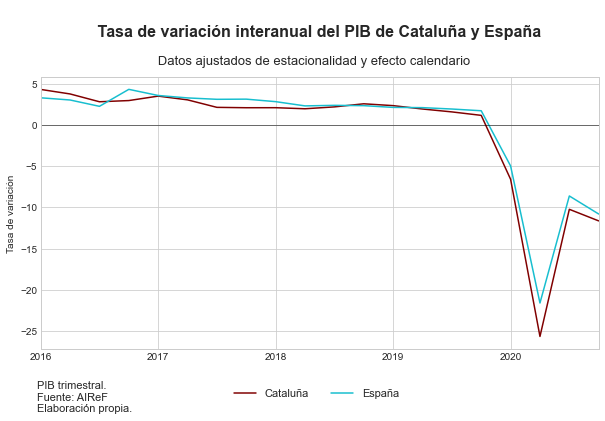

- El PIB venía experimentando una desaceleración en los últimos ejercicios económicos, con tasas de variación a la baja hasta finales de 2019.
- El impacto de la crisis sanitaria ha llevado a tasas de variación negativas excepcionalmente bajas, con mínimos en el segundo trimestre de 2020 menores al -20%.
- Cataluña ha resultado ligeramente más afectada por la crisis sanitaria que España, con tasas negativas por debajo del conjunto de España.

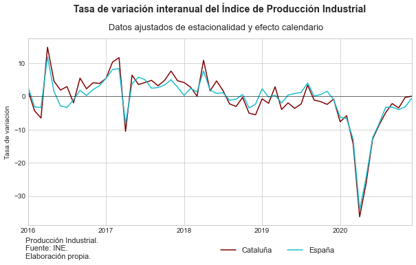

- El impacto de la crisis sanitaria ha llevado a tasas de variación negativas excepcionalmente bajas, con mínimos en el segundo trimestre de 2020 menores al -30% tanto en Cataluña como en el conjunto de España.

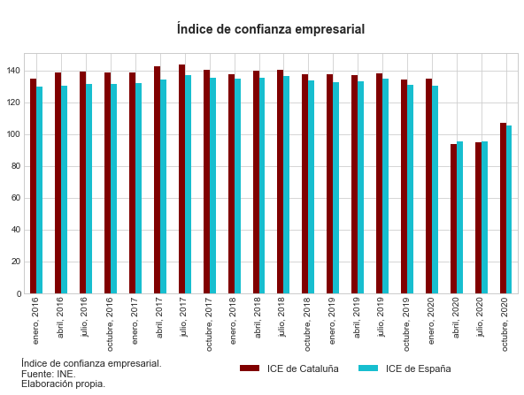

- La crisis sanitaria provocada por el COVID-19 ha llevado a una disminución de más de 30 puntos en el índice de confianza empresarial en el segundo y tercer trimestres del 2020, observándose cierta recuperación en el último trimestre del año.

### 3. Demanda:

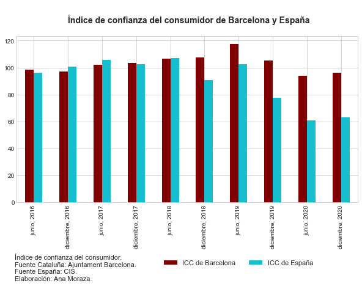

- Como aproximación a la confianza del consumidor en Cataluña, tomamos el índice proporcionado por el Ayuntamiento de Barcelona, el cual muestra una disminución de alrededor de 10 puntos en el primer semestre de 2020, aumentando ligeramente en el segundo semestre.
- En cuanto al indicador para el conjunto de España, este ha sufrido una caída de aproximadamente 20 puntos en el primer semestre de 2020, experimentando una mejoría muy leve en el segundo semestre.

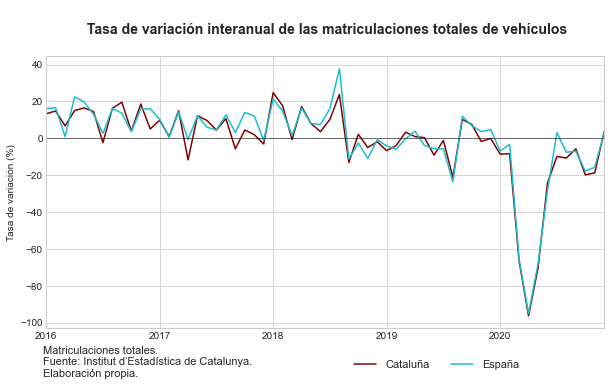

- Las matriculaciones de vehículos venían experimentando una desaceleración en los últimos ejercicios económicos, con tasas de variación a la baja hasta finales de 2019.
- El impacto de la crisis sanitaria ha llevado a tasas de variación negativas excepcionalmente bajas, con mínimos en el segundo trimestre de 2020 menores al -80%, con una notable recuperación en el último trimestre del año.

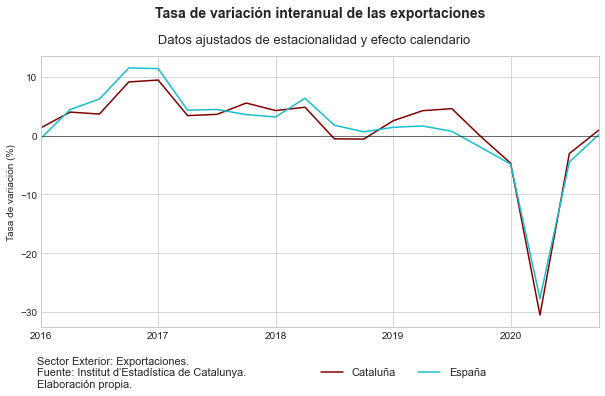

- Las exportaciones venían experimentando una desaceleración hasta finales de 2019.
- La crisis sanitaria provocada por el COVID-19 ha llevado a una disminución de cerca del 30% en el segundo trimestre del 2020.
- Los datos del último trimestre señalan tasas de variación ligeramente por encima del cero.

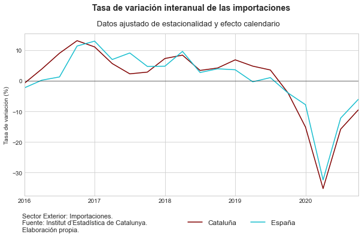

- La crisis sanitaria provocada por el COVID-19 ha llevado a una disminución de más del 30% de las importaciones en el segundo trimestre del 2020 con respecto al mismo trimestre del año anterior. Los dos siguientes trimestres han visto una recuperación del volumen de importaciones pero observándose todavía una tasa del -10% en el último trimestre.

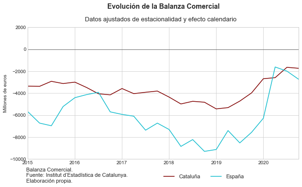

- La balanza comercial experimenta valores negativos durante todos los trimestres, indicando que tanto Cataluña como España importan más que exportan.
- En el último trimestre del año las exportaciones netas son de -1733 y -2739 para Cataluña y España, respectivamente.

### 4. Mercado de trabajo:

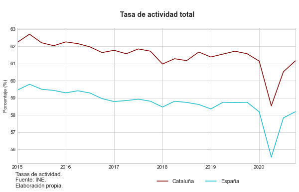

- El impacto de la crisis sanitaria ha provocado en ambas series un brusco descenso sin precedentes en el segundo trimestre de 2020.
- En el último trimestre del 2020 presentan una evolución favorable, recuperando buena parte del descenso sufrido.

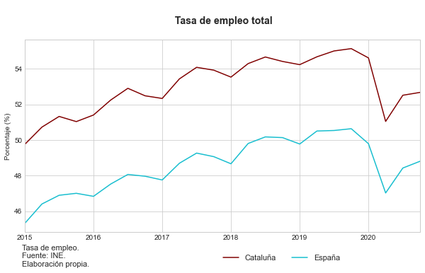

- La tasa de empleo venía experimentando un aumento gradual a lo largo del periodo representado.
- En el segundo trimestre del 2020, a causa de la crisis sanitaria del COVID-19, ambas series se ven afectadas por un brusco descenso, que ha sido parcialmente recuperado.

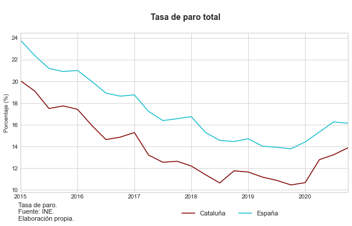

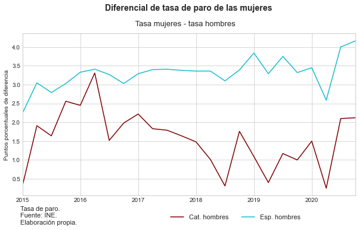

- La tasa de paro de las mujeres se encuentra sistemáticamente por encima de la tasa de los hombres, siendo este diferencial dos puntos superior en el conjunto de España.
- El diferencial se ha incrementado en los últimos trimestres, situándose en 2 y 4 puntos porcentuales en Cataluña y España, respectivamente.

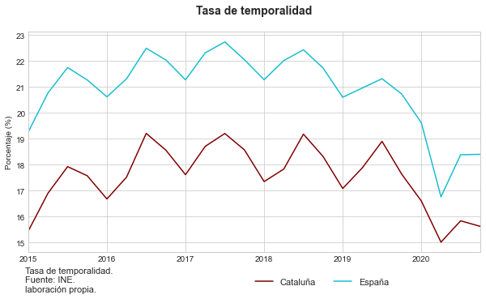

- En segundo trimestre del año 2020, debido a la crisis sanitaria, las series presentan un brusco descenso por la gran cantidad de despidos que hubo en ese periodo, los cuales afectaron en mayor medida a los trabajadores temporales.

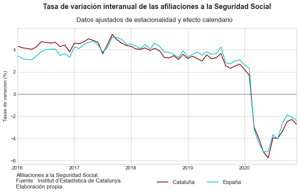

- La tasa de variación interanual de las afiliaciones a la Seguridad Social venía experimentando una desaceleración gradual hasta el año 2019.
- A causa de la crisis sanitaria del COVID-19, en el segundo trimestre del año 2020 las series presentan una variación del -6% aproximadamente, continuando el resto del año con variaciones por debajo del -2%.

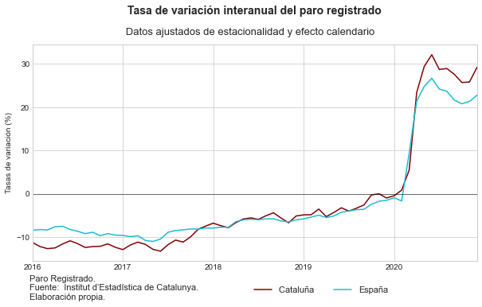

- Las series de Cataluña y España de paro registrado sufren un gran aumento debido a la crisis del COVID-19 en el segundo trimestre del año 2020, manteniéndose en tasas de variación por encima del 20% el resto del año.
- El aumento del paro registrado en Cataluña ha sido 6 puntos porcentuales superior al del conjunto de España.

### 5. Impacto de las crisis:

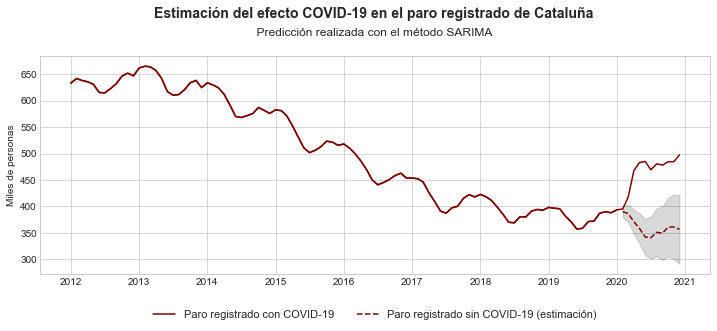

- El impacto de la crisis sanitaria ha supuesto un incremento estimado de 150.000 parados aproximadamente, lo que representa un aumento del 42% sobre el número de parados si no hubiera habido pandemia.

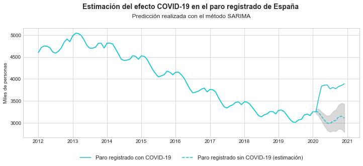

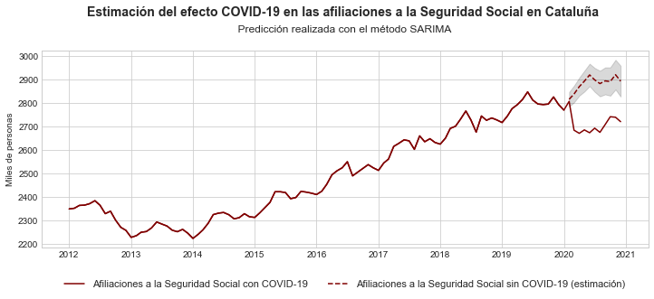

- El impacto de la crisis sanitaria en Cataluña ha supuesto alrededor de unas 200.000 afiliaciones menos, lo que representa una disminución del 7% aproximadamente respecto al valor estimado que hubiera habido sin pandemia.

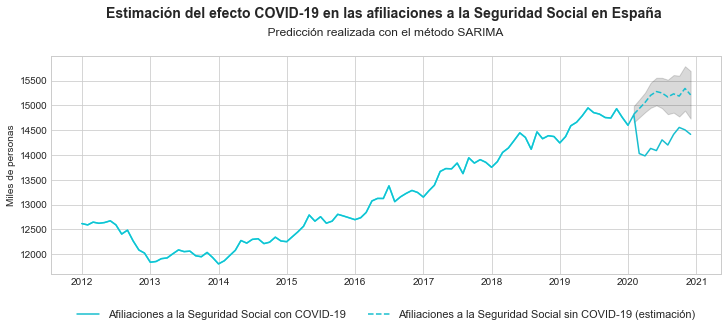

- El impacto de la crisis sanitaria en España ha supuesto alrededor de unas 750.000 afiliaciones menos, lo que representa una disminución del 5% aproximadamente respecto al valor estimado que hubiera habido sin pandemia.
- La disminución de las afiliaciones a la Seguridad Social a causa de la crisis sanitaria es 2 puntos porcentuales superior en Cataluña que en el conjunto de España